# Good coding practices

Insights North East Workshop

Clement Lee (Newcastle University)

2025-02-04 (Tue)

# Today’s outline

1. Introduction
   - The case for coding
   - Quick introduction to R
   - Basic plots
2. Practical 1
   - Carry out analysis of your data in R
3. Data pipeline via the **tidyverse**
4. Create documents / presentations in a **reproducible** way
5. Practical 2
   - Try to convert your analysis
6. Q & A, wrap-up
- Today’s slides: https://bit.ly/insights-north-east
- Some useful resources I have co-produced:
  - Literate programming: https://bit.ly/literate-programming
  - On converting outputs: https://bit.ly/bookdown2024
- Toolkits on https://insightsnortheast.co.uk/data/?

# 1. Introduction

# About me

- Lecturer in Statistics at Newcastle University since August 2022
- Teach statistical analysis using R
- Research on statistical models for (social) networks

# Experience with outside academia

- Case study: https://bit.ly/s4s-freegle

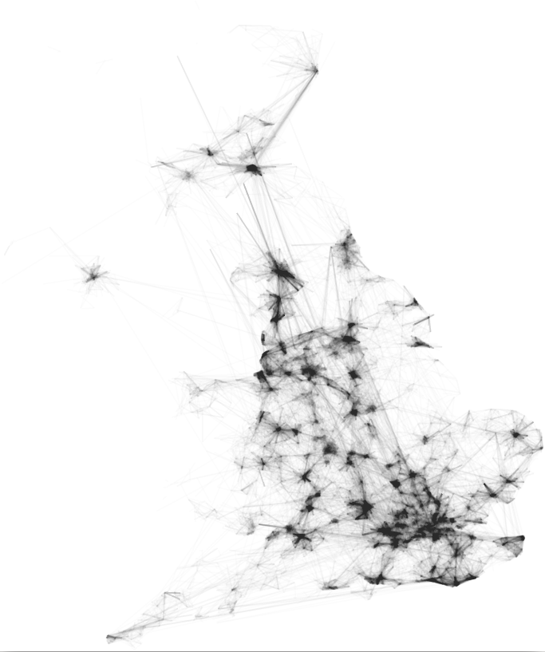

# About you?

- Write in the chat
- Experience in working with data, and what are your usual tools?
- Have you coded in R (or other programming languages) before?

# Why coding in the first place?

- Future-proof your analysis
  - for others to replicate / reproduce
  - including your future self
- ChatGPT & others making it easier to start
- Also the stepping stone for machine learning and AI
  - but don’t start with something completely unfamiliar
  - garbage in, garbage out
- Version control, CI/CD, and beyond

# Other kinds of output

- “*But I need to make presentations, reports, visualisations, etc.*”
- Most can be done nicely via R
- We will see how this can be done

# Why not Python?

- Python great for big data pipelines
  - Interfacing with the Internet
  - Machine learning at scale
- R is better in some other aspects
  - Standalone analysis
  - The whole data pipeline with `tidyverse`
  - The notebook / literate programming approach
- Understand which one is better / more suited for your tasks

# R

- Free & open source
- Download from https://cran.r-project.org/
- Anyone can contribute:
  - https://cran.r-project.org/web/packages/available_packages_by_name.html
  - Some packages about “business”, “politics”, etc.

# RStudio

- The (best) interface for using R
- Download from https://posit.co/download/rstudio-desktop/
- Let’s have a look

# Data

```r
library(readxl)
table1 <- read_xlsx("Business Rates properties - November 2024.xlsx")
table1
```

```
## # A tibble: 11,714 × 19
##     Year start               end   property code  street address
##    <dbl> <dttm>              <lgl> <chr>    <chr> <chr>  <chr>
##  1  2024 2017-02-10 00:00:00 NA    N000080  CW    582    Brunswick Park Industr…
##  2  2024 2020-08-01 00:00:00 NA    N000082  IM3   582    Brunswick Park Industr…
##  3  2024 2014-11-28 00:00:00 NA    N000085  CW    582    Antique Pine Imports, …
##  4  2024 2016-06-10 00:00:00 NA    N000087  IF    582    Brunswick Park Industr…
##  5  2024 1995-04-01 00:00:00 NA    N000088  IF    582    9, Brunswick Park Indu…
##  6  2024 2015-08-05 00:00:00 NA    N000090  CW    582    10, Brunswick Park Ind…
##  7  2024 1995-04-01 00:00:00 NA    N000093  IF3   582    Brunswick Park Industr…
##  8  2024 1995-04-01 00:00:00 NA    N000094  IF3   583    13, Brunswick Village,…
##  9  2024 1995-04-01 00:00:00 NA    N000095  IF3   582    Brunswick Park Industr…
## 10  2024 2019-01-01 00:00:00 NA    N000096  CW    12979  Unit 15, Brunswick Par…
## # ℹ 11,704 more rows
## # ℹ 12 more variables: `NEW foi_liable party` <chr>, `NEW c/o address` <chr>,
## #   `rateable value` <dbl>, LIA <dbl>, TRL <dbl>, SBR <dbl>, Chr <dbl>,
## #   s44a <lgl>, EXM <dbl>, DRR1 <lgl>, DRR2 <dbl>, `net charges` <dbl>
```

- Source: https://new.newcastle.gov.uk/budget-policies-performance-data/open-data/business-economy/business-rates-data/all-current-business-rates-properties
- A table / spreadsheet in Excel (.xls, .xlsx, .csv, …) $\approx$ a **data frame** / **tibble** in R

# Some summary statistics

```r
mean(table1$`rateable value`) # the average of rateable value
```

```
## [1] 28322.39
```

```r
sd(table1$`LIA`) # standard deviation of variable LIA
```

```
## [1] 78594.26
```

```r
summary(table1$`net charges`) # a range of summaries
```

```
##    Min. 1st Qu.  Median    Mean 3rd Qu.    Max.
##       0       0     419   10380    3898 3598140
```

# A histogram

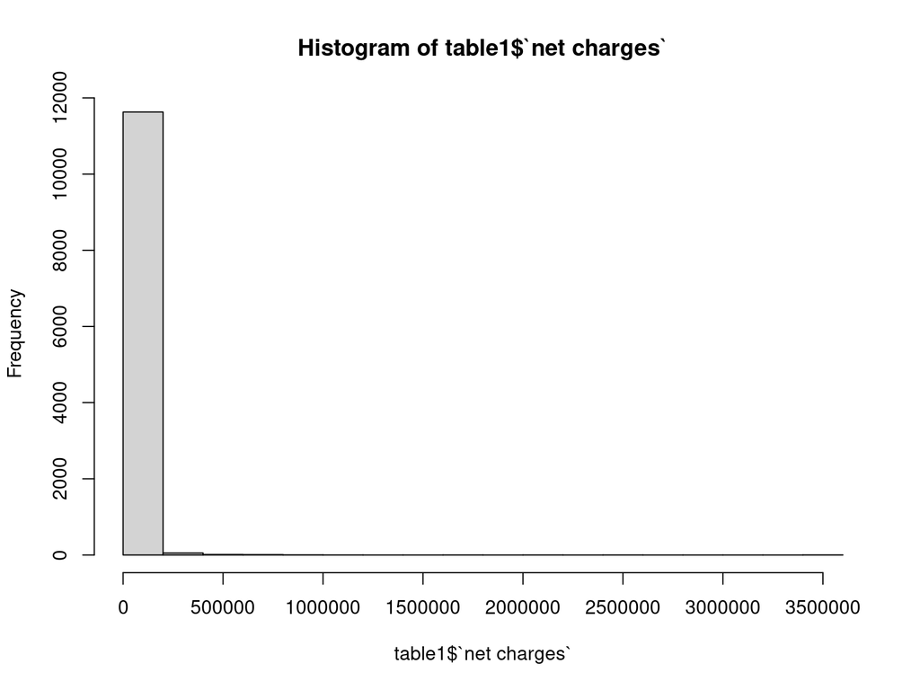

```r
hist(table1$`net charges`) # histogram of net charges
```

# Better

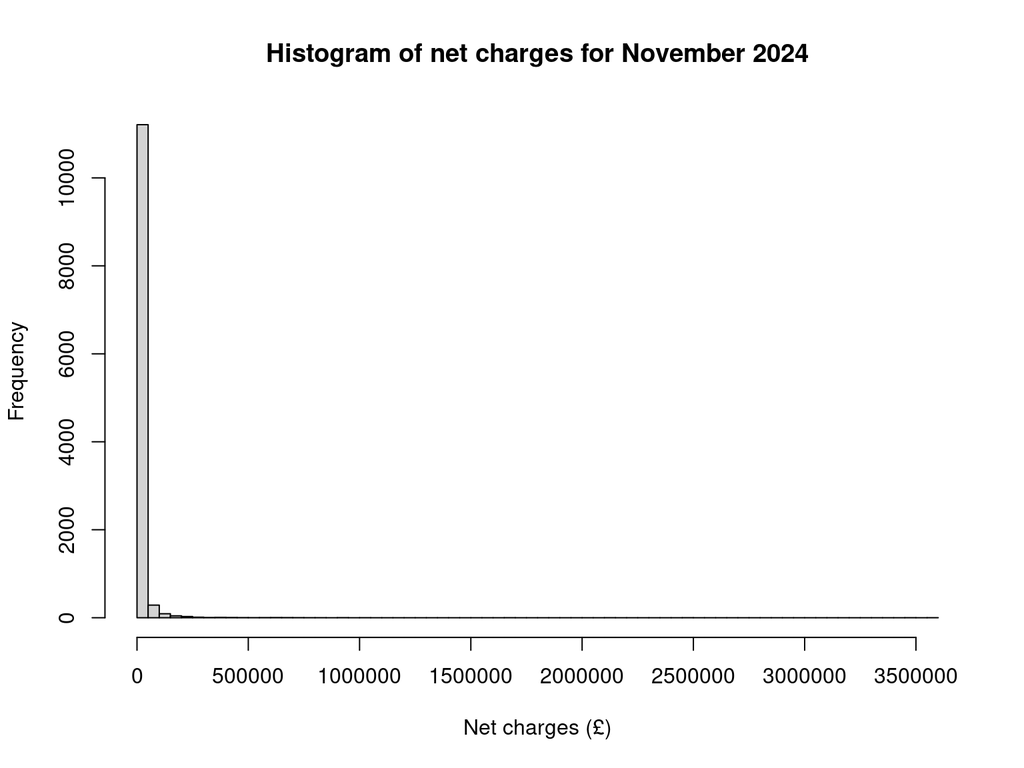

```r
hist(table1$`net charges`,
     breaks = 100, # approximately 100 bars
     main = NA, xlab = NA) # don't print the title and the x-axis label yet
title(main = "Histogram of net charges for November 2024",
      xlab = "Net charges (£)")
```

# Dates / times

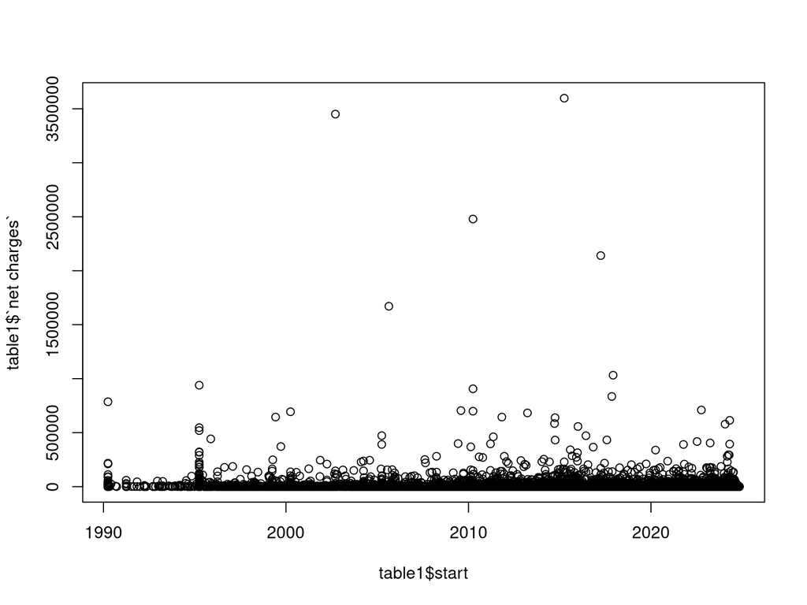

```r
plot(table1$start, table1$`net charges`)
```

# Better

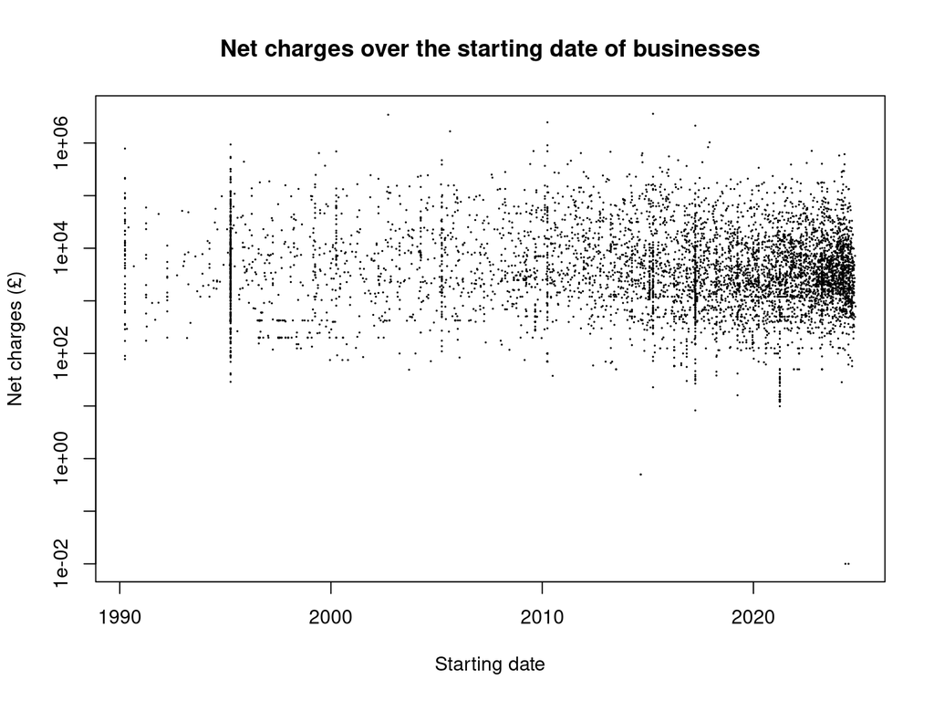

```r
plot(table1$start, table1$`net charges`, log = "y", # on log scale
     main = NA, xlab = NA, ylab = NA, # don't print title & axis labels yet
     cex = 0.1) # size of the points
title(main = "Net charges over the starting date of businesses",
      xlab = "Starting date", ylab = "Net charges (£)")
```

# Preempting the questions

- What if we have an xls or csv file instead?
- `read_xls()` from the same package `readxl`
- `read.csv()` that comes with R

# Preempting the questions

- What if we want to create new columns (by manipulating some existing columns) and plot them?
- Tedious if we need to
  - create them first,
  - re-save the spreadsheet,
  - and then rerun the analysis
- It is usually the best **not** to modify the raw / original data.

# Preempting the questions

- Plots still not perfect
- Huge skew of `net charges` $\rightarrow$ uninformative histogram; perhaps log scale help?
- Faffy modifications; instead, we will use the package `ggplot2`

# Preparing for the next section

- We can build a data pipeline within R to
  - read the data,
  - manipulate them, and
  - make very nice plots
- Tidyverse (https://www.tidyverse.org/), arguably the biggest development in R **ever**
  - `ggplot2` is part of it

# Questions so far?

- Also, too fast or too slow?

# Practical 1

- Go to https://bit.ly/insights-practical1
- Go through the practical in groups
- Make summaries and plots using your own data or the business rates data
  - Think about what you want to highlight
- Note any challenges / difficulties, or anything you find useful
- Report your findings